### What is the quality control (QC) workflow?

Upon upload, interactive volcano plot and scatter plot will be generated. The scatter plot is only applicable if the user input file includes rep1 and rep2 values. Hovering over each marker will show the corresponding gene name in HGNC symbol. Genes of interest can be searched for on the interactive plots using the search function on the side panel. Genoppi interface with sample input file loaded is shown below.

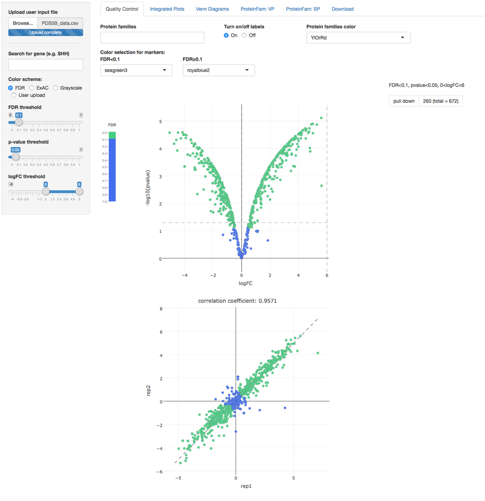

Table to the right of volcano plot shows the count of interactors enriched in regions specified by the threshold controllers on the left panel.

The initial FDR threshold for color scale is 0.1. Results are shown as a volcano plot where logFC values of the bait versus control condition are plotted on the x-axis and the negative log10 transformed P values of that enrichment are plotted on the y-axis. Interaction partners that are enriched in the experiment with an FDR < 0.1 are green, and interaction partners with an FDR >= 0.1 are blue. Upon selection of new FDR value on the left panel, the interactive plots will render with the new color scale reflecting new FDR threshold value. User is able to change the colors determined by FDR threshold using “color selection for markers” as shown below.

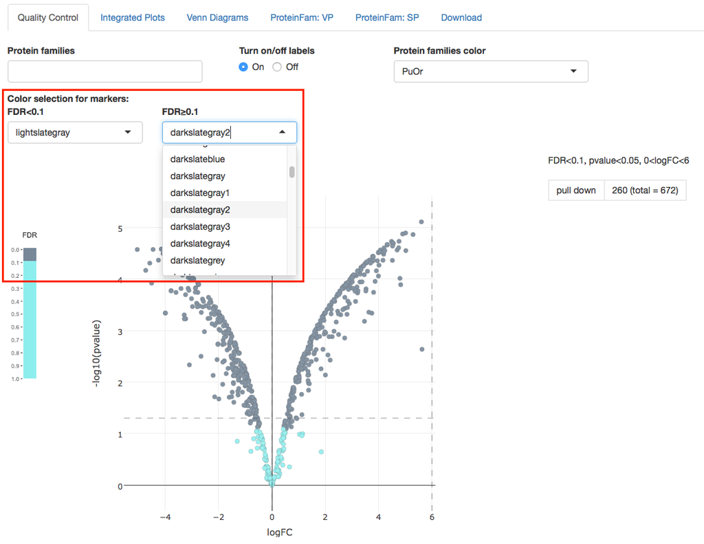

For convenience, markers can also be colored in grayscale, by ExAC pLI scores, or by user uploaded scores (details below).

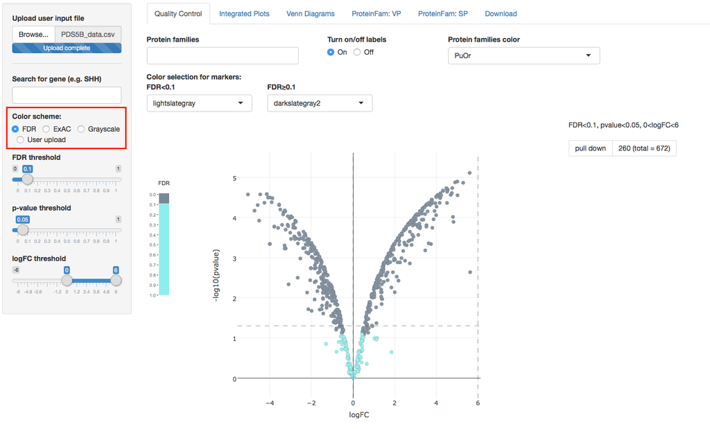

Visualizing using the “ExAC” color scheme helps to identify proteins encoded by genes likely to be extremely intolerant to loss-of-function (LoF) variation using the ExAC pLI scores. Genes marked as pLI >= 0.9 are defined as extremely LoF intolerant set of genes. Genes marked as pLI < 0.9 are defined as LoF tolerant set of genes.

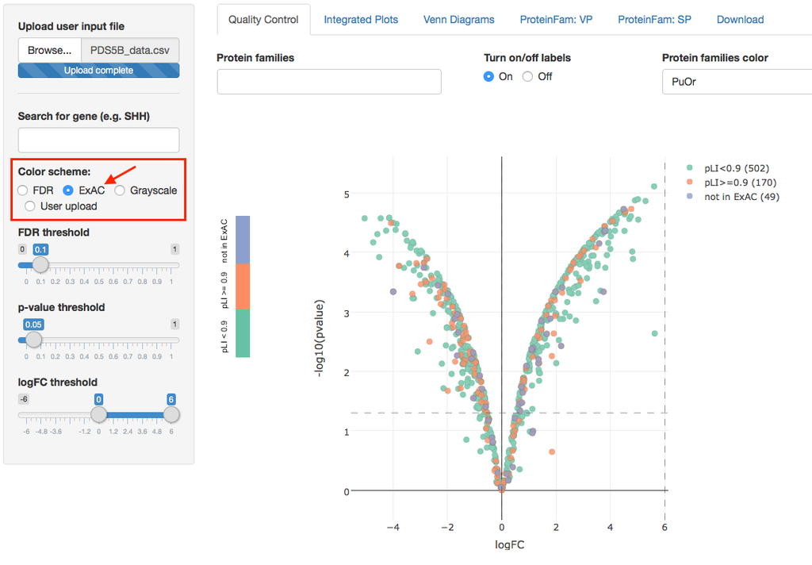

“User upload” color scheme allows user to upload genes and their associated values. For example, user can upload external datasets such as Project Achilles, or RNA-Seq expression value associated with genes as a text file. The files must be in tabular format as delimited text with column headers of ‘gene’ and ‘score’ and expected values as shown below.

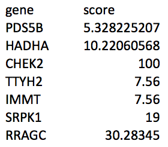

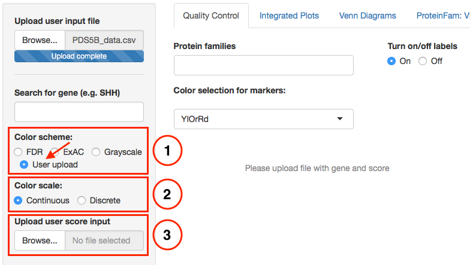

Discrete color scale assigns different colors to each scores reported in user file and continuous color scale creates a gradient between the minimum and maximum scores reported. Upon user score input, the proteomics data will be visualized using the user-uploaded score. The color theme can then be changed using ‘color selection for markers.’ The example plot shown below is plotted using the YlGnBu (YellowGreenBlue) color theme.

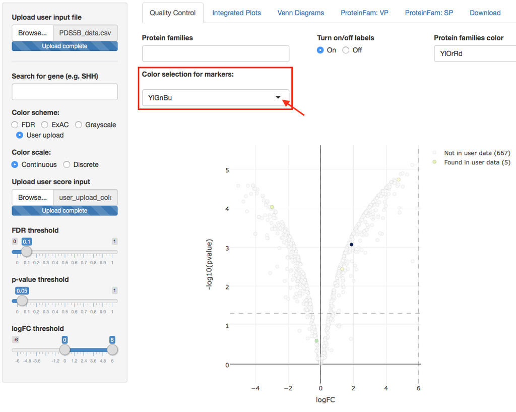

### Protein families removal

The “Protein families” field in QC panel is a cleanup function designed to QC by removing protein family members considered as contaminants or sticky proteins. Protein family lists are taken from the HGNC database, curated by the HGNC appointed team. This feature is only available if the input data contains either HGNC approved symbol or UniProt accession numbers with logFC values for two replicates observed in the IP experiment.

The drop down menu shows all protein families present in the HGNC database and multiple protein families can be selected. Any matching proteins in user data from the selected protein family will be highlighted and appear on the legend. The matching protein families coloring can be changed using ‘protein families color’ drop down menu.

If there are any matches, the “Remove selected PF from input” button will appear and user is able to download an updated proteomics data where the proteins belonging to the chosen protein families are removed.

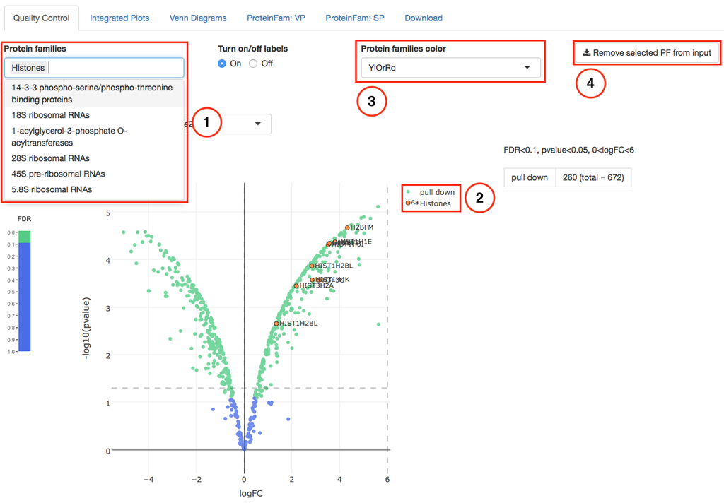

### Overlay known protein interactors from InWeb

User can further QC by identifying known human protein interaction partners from [InWeb](http://www.nature.com/nmeth/journal/v14/n1/abs/nmeth.4083.html) ([download InWeb](https://www.intomics.com/inbio/map/#downloads)), which contains known protein-protein interactions from >40,000 articles. Overlaying this information with the experimental data enables users to easily distinguish new interactions from those already reported in the literature. Known interaction partners of the bait protein, as determined by overlaying InWeb data, are highlighted in yellow in the figure below.

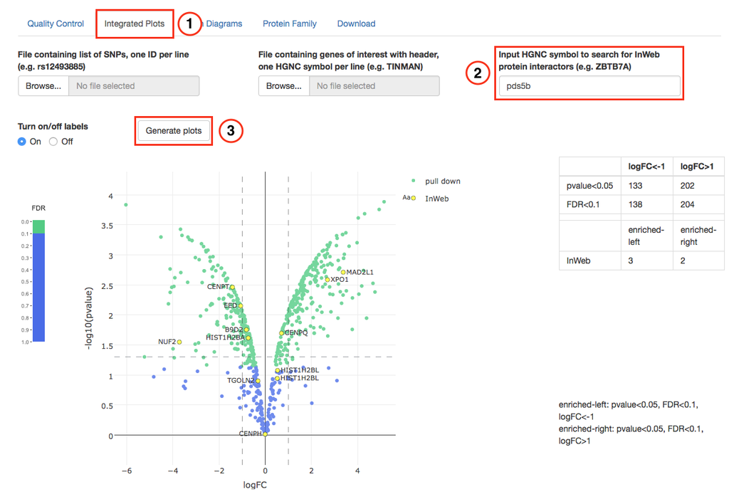